# Police Use of Force, Minneapolis

Open Data Minneapolis

This is a preliminary analysis of Police Use of Force data obtained from Open Data Minneapolis. (link: http://opendata.minneapolismn.gov/datasets/police-use-of-force). It has basic vizualisations.

```r
library(dplyr)
```

```r
library(ggplot2)

pof <- read.csv("~/Documents/Police_accountability/Police_Use_of_Force.csv")
```

Number of null values for each variable:

```r
sapply(pof, function(x) sum(is.na(x)))
```

```
##                             X                             Y
##                             0                             0
##            PoliceUseOfForceID                    CaseNumber
##                             0                             0
##                  ResponseDate                       Problem
##                             0                             0
##                     Is911Call                PrimaryOffense
##                             0                             0
##                 SubjectInjury             ForceReportNumber
##                             0                             0
##                   SubjectRole             SubjectRoleNumber
##                             0                            17
##                     ForceType               ForceTypeAction
##                             0                             0
##                          Race                           Sex
##                             0                             0
##                      EventAge              TypeOfResistance
##                          1670                             0
##                      Precinct                  Neighborhood
##                             0                             0
##         TotalCityCallsForYear     TotalPrecinctCallsForYear
##                             0                          1131
## TotalNeighborhoodCallsForYear                   CenterGBSID
##                             0                             0
##                CenterLatitude               CenterLongitude
##                             0                             0
##                       CenterX                       CenterY
##                             0                             0
##                     DateAdded                      OBJECTID
##                             0                             0
```

```r
# getting dates from ResponseDate
pof$Date <- as.Date(pof$ResponseDate)

# creating separate variables for the year and month
pof$Year <- format(as.Date(pof$Date, format="%d/%m/%Y"),"%Y")
pof$Month <- format(as.Date(pof$Date, format="%d/%m/%Y"),"%m")

pof$Year <- as.factor(pof$Year)
```

### By year

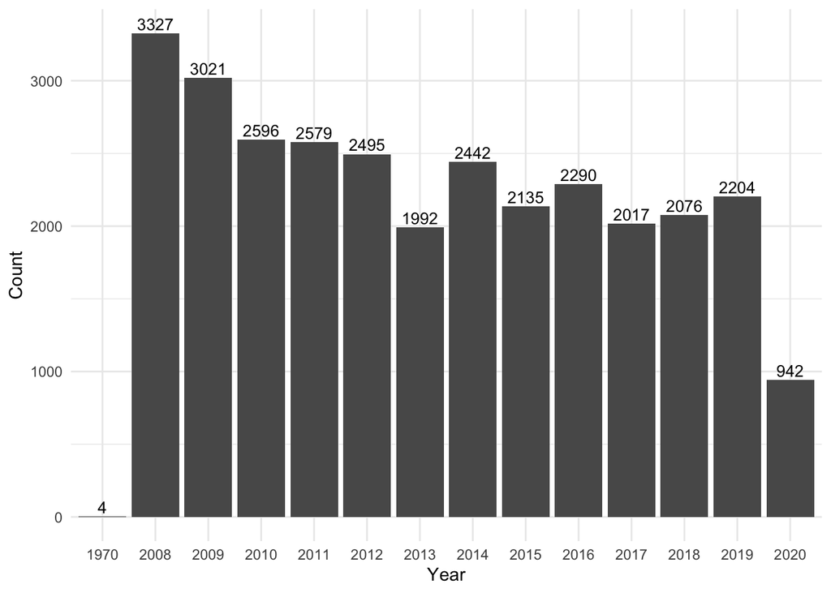

```r
# create a data frame for counts by year
year_counts <- pof %>%
  group_by(Year) %>%
  summarise(n())

colnames(year_counts) <- c("Year", "Count")

# plot number of observations by year
ggplot(data=year_counts, aes(x=Year, y=Count)) + geom_bar(stat="identity") +
  geom_text(aes(label=Count), vjust=-0.3, size=3.5) + theme_minimal()
```

How many months of data is available for 2020? Do all other years (except 1970) have atleast one data point from each month?

```r
print(unique(pof$Month[pof$Year == 2020])) # first 6 months of the year
```

```
## [1] "01" "02" "03" "04" "05" "06"
```

```r
print(pof %>% group_by(Year) %>% summarise(n_distinct(Month)))
```

```
## # A tibble: 14 x 2
##    Year  `n_distinct(Month)`
##    <fct>               <int>
##  1 1970                    1
##  2 2008                   12
##  3 2009                   12
##  4 2010                   12
##  5 2011                   12
##  6 2012                   12
##  7 2013                   12
##  8 2014                   12
##  9 2015                   12
## 10 2016                   12
## 11 2017                   12
## 12 2018                   12
## 13 2019                   12
## 14 2020                    6
```

### Primary Offenses

Number of unique primary offenses:

```r
# removal of possible trailing whitespaces
pof$PrimaryOffense <- trimws(pof$PrimaryOffense) #present

print(length(unique(pof$PrimaryOffense)))
```

```
## [1] 206
```

For a list of Common Abbreviations Used in Criminal Record Reports refer to this pdf. (link: https://www.cdse.edu/documents/cdse/CriminalRecordAbbreviations.pdf)

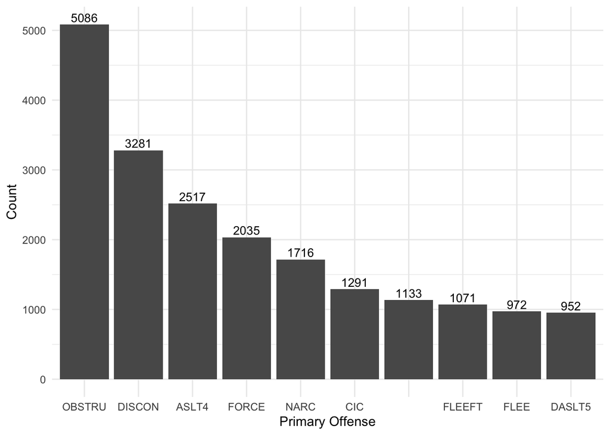

```r
# visualise top 10 primary offenses

primoff <- pof %>%
  group_by(PrimaryOffense) %>%
  summarise(n())

colnames(primoff) <- c("PrimOff", "Count")

primoff <- primoff[order(-primoff$Count), ]

ggplot(data=primoff[1:10,], aes(x=reorder(PrimOff, -Count), y=Count)) + xlab("Primary Offense") +
  geom_bar(stat="identity") + geom_text(aes(label=Count), vjust=-0.3, size=3.5) + theme_minimal()
```

### Problem

What problem occured?

Number of unique problems encountered:

```r
# removal of possible trailing whitespaces
pof$Problem <- trimws(pof$Problem) #absent

print(length(unique(tolower(pof$Problem))))
```

```
## [1] 126
```

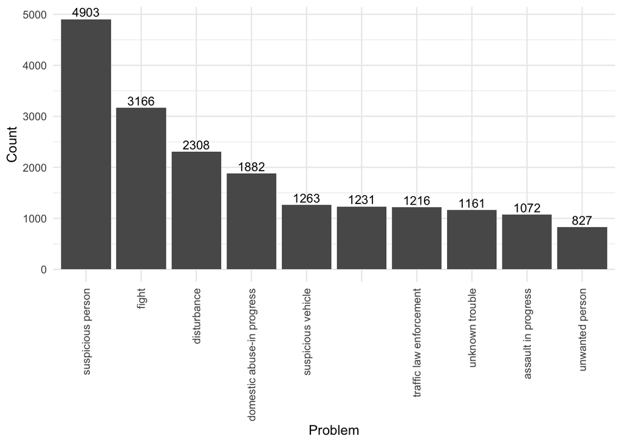

```r
# visualise top 10 problems

probs <- pof %>%
  group_by(tolower(Problem)) %>%
  summarise(n())

colnames(probs) <- c("Problem", "Count")

probs <- probs[order(-probs$Count), ]

ggplot(data=probs[1:10,], aes(x=reorder(Problem, -Count), y=Count)) +
  geom_bar(stat="identity") + geom_text(aes(label=Count), vjust=-0.3, size=3.5) + xlab("Problem") + theme_minimal() + theme(axis.text.x = element_text(angle = 90, vjust = 0.5, hjust=1))
```

### Types of Force and Force Actions

What type of force was used?

```r
# removal of possible trailing whitespaces
pof$ForceType <- trimws(pof$ForceType) #absent

print(unique(tolower(pof$ForceType)))
```

```
##  [1] "bodily force"                "chemical irritant"
##  [3] "taser"                       "baton"
##  [5] "improvised weapon"           "police k9 bite"
##  [7] "firearm"                     "less lethal projectile"
##  [9] "gun point display"           "maximal restraint technique"
## [11] ""                            "less lethal"
```

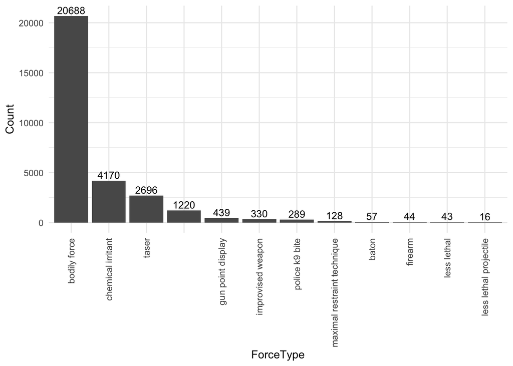

```r
# visualise type of force

force <- pof %>%
  group_by(tolower(ForceType)) %>%
  summarise(n())

colnames(force) <- c("Force", "Count")

force <- force[order(-force$Count), ]

ggplot(data=force, aes(x=reorder(Force, -Count), y=Count)) +
  geom_bar(stat="identity") + geom_text(aes(label=Count), vjust=-0.3, size=3.5) + xlab("ForceType") + theme_minimal() + theme(axis.text.x = element_text(angle = 90, vjust = 0.5, hjust=1))
```

What force type action was made?

```r
# force type actions fall under force type i.e. each force type has a set of actions that can be associated with it
options(width=20)

#removal of possible trailing whitespaces from force type action
pof$ForceTypeAction <- trimws(pof$ForceTypeAction) #absent

forceact <- pof %>% group_by(tolower(ForceType), tolower(ForceTypeAction)) %>% summarise(n())

colnames(forceact)[3] <- "Count"
forceact <- forceact[order(-forceact$Count),]
print(forceact)
```

```
## # A tibble: 51 x 3
## # Groups:
## #   tolower(ForceType)
## #   [12]
##    `tolower(ForceT…
##    <chr>
##  1 bodily force
##  2 bodily force
##  3 bodily force
##  4 chemical irrita…
##  5 bodily force
##  6 bodily force
##  7 chemical irrita…
##  8 taser
##  9 bodily force
## 10 bodily force
## # … with 41 more
## #   rows, and 2
## #   more variables:
## #   `tolower(ForceTypeAction)` <chr>,
## #   Count <int>
```

### Type of Resistance

How did the subject resist?

```r
# this field has trialing whitespaces, remove them
pof$TypeOfResistance <- trimws(pof$TypeOfResistance) #present

# tensed, Tensed, TENSED - convert all to lower case
print(unique(tolower(pof$TypeOfResistance)))
```

```
##  [1] "fled in vehicle"
##  [2] "assaulted officer"
##  [3] "tensed"
##  [4] "verbal non-compliance"
##  [5] "fled on foot"
##  [6] "unspecified"
##  [7] "commission of crime"
##  [8] "assaulting police horse"
##  [9] "assaulting police k9"
## [10] ""
## [11] "other"
## [12] "commission of a crime"
## [13] "fled in a vehicle"
## [14] "assaulted police horse"
```

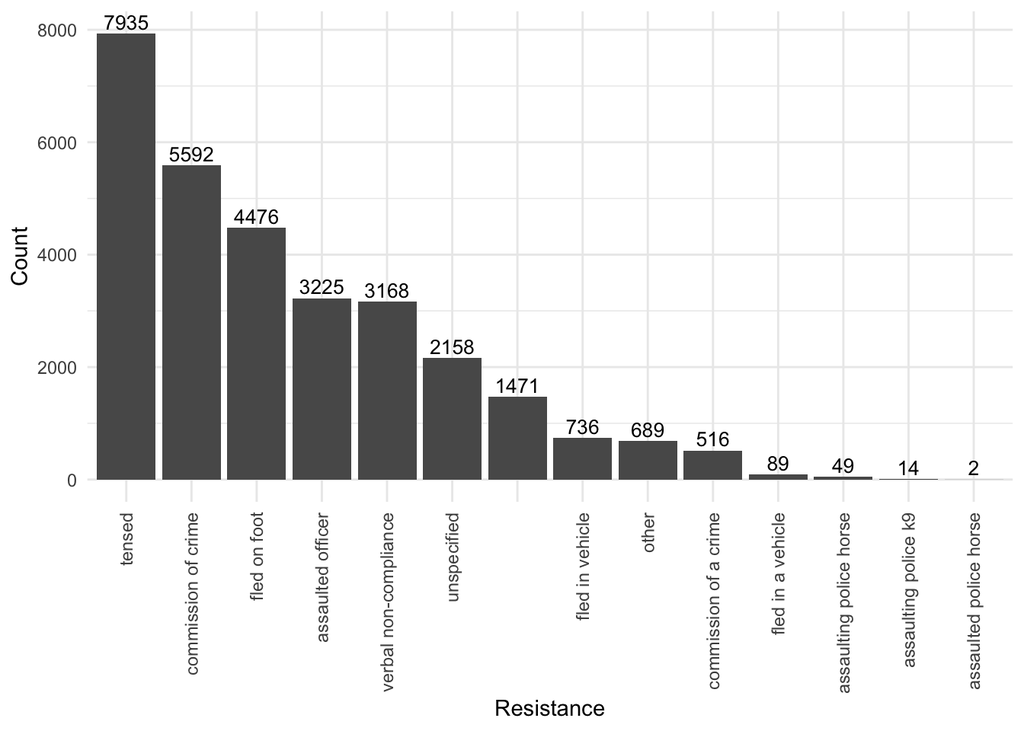

```r
# visualise type of force

res <- pof %>%
  group_by(tolower(TypeOfResistance)) %>%
  summarise(n())

colnames(res) <- c("Resistance", "Count")

res <- res[order(-res$Count), ]

ggplot(data=res, aes(x=reorder(Resistance, -Count), y=Count)) +
  geom_bar(stat="identity") + geom_text(aes(label=Count), vjust=-0.3, size=3.5) + xlab("Resistance") + theme_minimal() + theme(axis.text.x = element_text(angle = 90, vjust = 0.5, hjust=1))
```

```r
# relation between type of resistance and type of force used
fores <- pof %>% group_by(tolower(TypeOfResistance), tolower(ForceType)) %>% summarise(n())
colnames(fores) <- c("Resistance", "Force", "Count")

print("Grouped by Resistance")
```

```
## [1] "Grouped by Resistance"
```

```r
fores %>% ungroup() %>% group_by(Resistance) %>% filter(Count == max(Count))
```

| Resistance | Force | Count |
| --- | --- | --- |
|  |  | 1220 |
| assaulted officer | bodily force | 2612 |
| assaulted police horse | chemical irritant | 1 |
| assaulted police horse | less lethal | 1 |
| assaulting police horse | bodily force | 33 |
| assaulting police k9 | bodily force | 7 |
| assaulting police k9 | police k9 bite | 7 |
| commission of a crime | bodily force | 295 |
| commission of crime | bodily force | 3136 |
| fled in a vehicle | bodily force | 77 |

[output cut: 6 more lines]

```r
print("Grouped by Force")
```

```
## [1] "Grouped by Force"
```

```r
fores %>% ungroup() %>% select(Force, Resistance, Count) %>% group_by(Force) %>% filter(Count == max(Count))
```

| Force | Resistance | Count |
| --- | --- | --- |
|  |  | 1220 |
| less lethal | assaulted officer | 26 |
| baton | commission of crime | 20 |
| chemical irritant | commission of crime | 1649 |
| firearm | commission of crime | 16 |
| gun point display | commission of crime | 118 |
| less lethal projectile | commission of crime | 7 |
| improvised weapon | fled on foot | 85 |
| police k9 bite | fled on foot | 125 |
| maximal restraint technique | other | 41 |

[output cut: 2 more lines]

Possibly, some more analysis can be done for Force and Resistance.

### Was a 911 call made?

```r
print(pof %>% group_by(Is911Call) %>% summarise(n()))
```

```
## # A tibble: 3 x 2
##   Is911Call `n()`
##   <chr>     <int>
## 1 ""         1135
## 2 "No"      16303
## 3 "Yes"     12682
```

Was the subject injured?

```r
print(pof %>% group_by(SubjectInjury) %>% summarise(n()))
```

```
## # A tibble: 3 x 2
##   SubjectInjury
##   <chr>
## 1 ""
## 2 "No"
## 3 "Yes"
## # … with 1 more
## #   variable:
## #   `n()` <int>
```

Is it surprising that there are so many cases where this data is unavailable?

Breaking down these values by year:

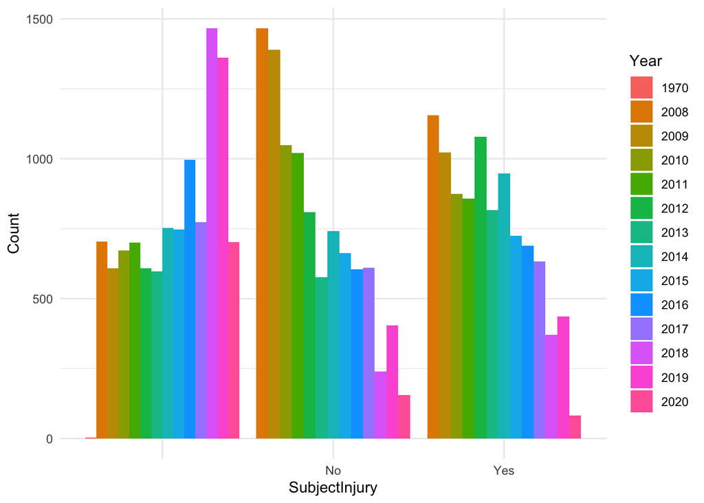

```r
subinyear <- pof %>% group_by(SubjectInjury, Year) %>% summarise(n())
colnames(subinyear)[3] <- "Count"

ggplot(data=subinyear, aes(x=SubjectInjury, y=Count, fill=Year)) +
  geom_bar(stat="identity", position=position_dodge()) + theme_minimal()
```

## By Race

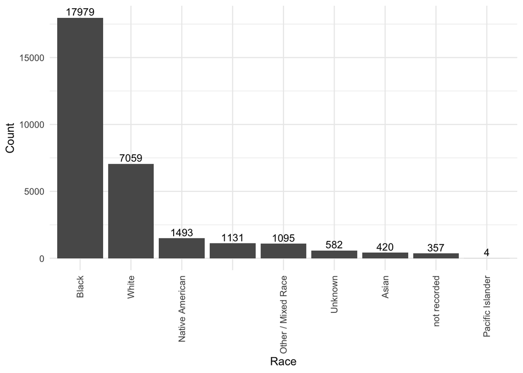

```r
race <- pof %>%
  group_by(Race) %>%
  summarise(n())

colnames(race) <- c("Race", "Count")

race <- race[order(-race$Count), ]

ggplot(data=race, aes(x=reorder(Race, -Count), y=Count)) +
  geom_bar(stat="identity") + geom_text(aes(label=Count), vjust=-0.3, size=3.5) + xlab("Race") + theme_minimal() + theme(axis.text.x = element_text(angle = 90, vjust = 0.5, hjust=1))
```

These are absolute counts but a next step would be to get percentages w.r.t overall population. (There are many years here so some sort of aggregation can be done to get these estimates) It’s already apparent though that disproportionality exists.

(In 2020, Minnesota is 83.3% white, 6.19% black, 4.75% asian, 1.07% Native American, 0.04% Native Hawaiian or Pacific Highlander, 2.85% mixed race and 1.77% with unknown race. Source: https://worldpopulationreview.com/states/minnesota-population/)

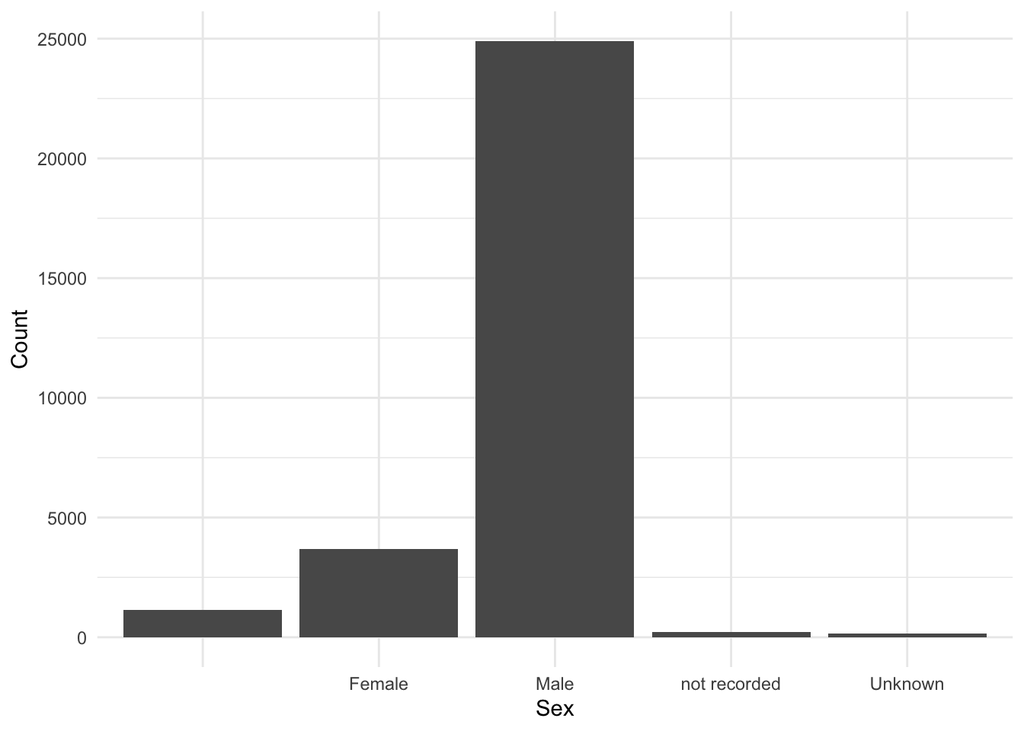

```r
sex <- pof %>% group_by(Sex) %>% summarise(n())

colnames(sex) <- c("Sex", "Count")

ggplot(data=sex, aes(x=Sex, y=Count)) +
  geom_bar(stat="identity") + theme_minimal()
```

### Age Distribution

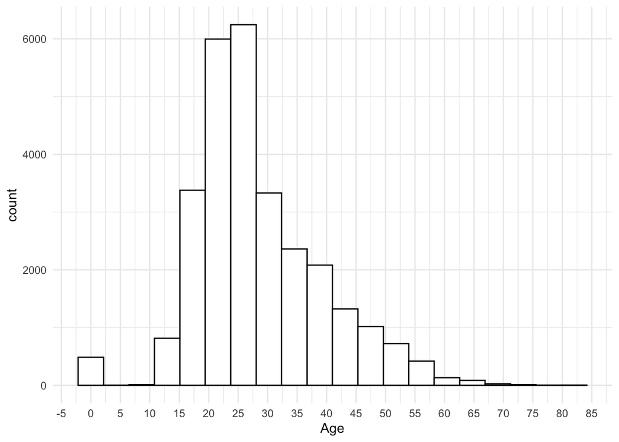

```r
age <- data.frame(subset(pof$EventAge, (pof$EventAge >= 0 & !(is.na(pof$EventAge)))))

colnames(age) <- "Age"

ggplot(data=age, aes(x=Age)) +
  geom_histogram(position="identity", bins=20, colour="black", fill="white") +
  scale_x_continuous(n.breaks=20) + theme_minimal()
```

### Negihbourhoods

Are there any neighbourhoods that experienced the highest use of police force?

```r
print(length(unique(pof$Neighborhood)))
```

```
## [1] 88
```

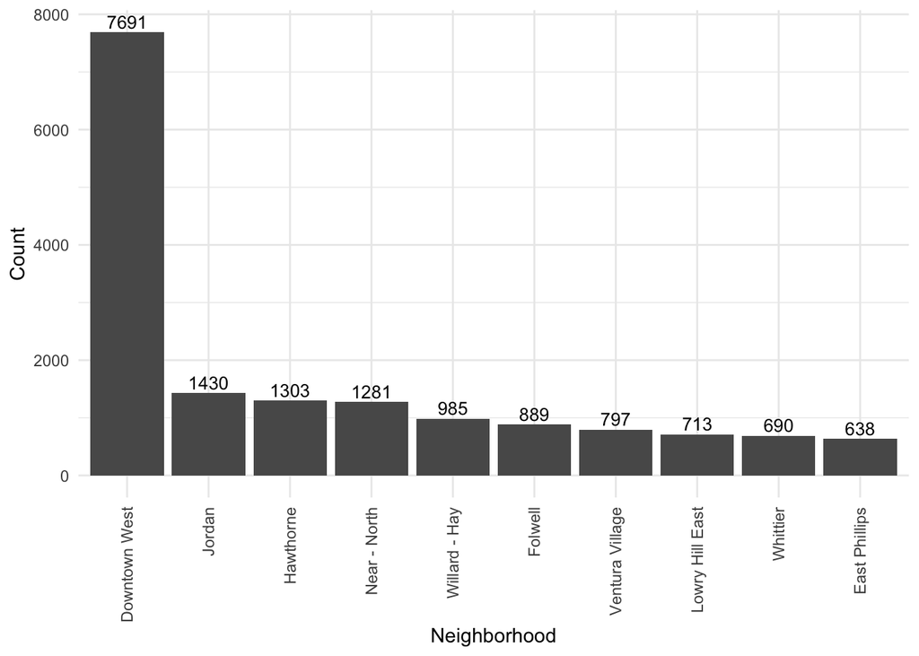

```r
# visualise top 10 neighbourhoods

nbr <- pof %>%
  group_by(Neighborhood) %>%
  summarise(n())

colnames(nbr) <- c("Neighborhood", "Count")

nbr <- nbr[order(-nbr$Count), ]

ggplot(data=nbr[1:10,], aes(x=reorder(Neighborhood, -Count), y=Count)) +
  geom_bar(stat="identity") + geom_text(aes(label=Count), vjust=-0.3, size=3.5) + xlab("Neighborhood") + theme_minimal() + theme(axis.text.x = element_text(angle = 90, vjust = 0.5, hjust=1))
```